# Omega Gender Equality

2020-09-07

**Return to [Portfolio site](https://johanna-jeffery-portfolio.netlify.app)**

# Omega Group plc- Pay Discrimination

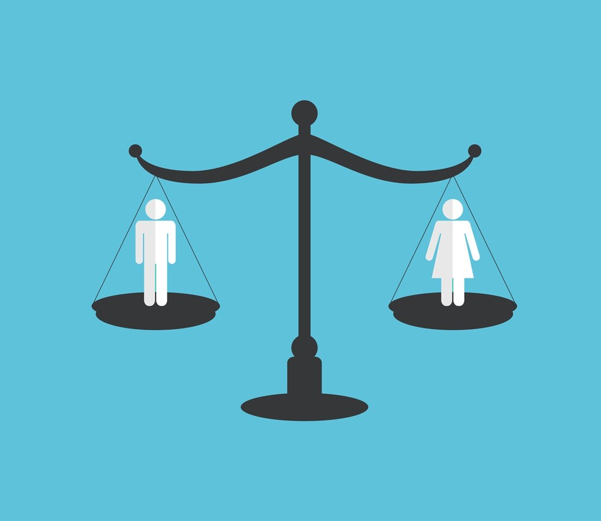

At the last board meeting of Omega Group Plc., the headquarters of a large multinational company, the issue was raised that women were being discriminated in the company, in the sense that the salaries were not the same for male and female executives. A quick analysis of a sample of 50 employees (of which 24 men and 26 women) revealed that the average salary for men was about 8,700 higher than for women. This seemed like a considerable difference, so it was decided that a further analysis of the company salaries was warranted.

In this case study we were asked to carry out the analysis.The objective was to find out whether there is indeed a significant difference between the salaries of men and women, and whether the difference is due to discrimination or whether it is based on another, possibly valid, determining factor.

## Loading the data

```r
omega <- read_csv(here::here("data", "omega.csv"))
glimpse(omega) # examine the data frame
```

```
## Rows: 50
## Columns: 3
## $ salary     <dbl> 81894, 69517, 68589, 74881, 65598, 76840, 78800, 70033, 63…
## $ gender     <chr> "male", "male", "male", "male", "male", "male", "male", "m…
## $ experience <dbl> 16, 25, 15, 33, 16, 19, 32, 34, 1, 44, 7, 14, 33, 19, 24, …
```

## Relationship Salary - Gender ?

First we calculated summary statistics on salary by gender and created and printed a dataframe where, for each gender, we show the mean, SD, sample size, the t-critical, the SE, the margin of error, and the low/high endpoints of a 95% confidence interval

```r
# Summary Statistics of salary by gender
mosaic::favstats (salary ~ gender, data=omega)
```

```
##   gender   min    Q1 median    Q3   max  mean   sd  n missing
## 1 female 47033 60338  64618 70033 78800 64543 7567 26       0
## 2   male 54768 68331  74675 78568 84576 73239 7463 24       0
```

```r
# Dataframe with two rows (male-female) and having as columns gender, mean, SD, sample size,
# the t-critical value, the standard error, the margin of error,
# and the low/high endpoints of a 95% confidence interval
omega_gender_ci <- omega %>%
  group_by(gender) %>%
  summarise(mean_salary = mean(salary),
            sd_salary = sd(salary),
            sample_size = n(),
            # get t-critical value with (n-1) degrees of freedom
            t_critical = qt(0.975, sample_size-1),
            se_salary = sd(salary)/sqrt(sample_size),
            margin_of_error = t_critical * se_salary,
            salary_low = mean_salary - margin_of_error,
            salary_high = mean_salary + margin_of_error
  ) %>%
  arrange(desc(mean_salary))
omega_gender_ci
```

```
## # A tibble: 2 x 9
##   gender mean_salary sd_salary sample_size t_critical se_salary margin_of_error
##   <chr>        <dbl>     <dbl>       <int>      <dbl>     <dbl>           <dbl>
## 1 male        73239.     7463.          24       2.07     1523.           3151.
## 2 female      64543.     7567.          26       2.06     1484.           3056.
## # … with 2 more variables: salary_low <dbl>, salary_high <dbl>
```

```r
set.seed(1234)
female_boot_salary <- omega %>%
  filter(gender == "female") %>%
  specify(response = salary) %>%
  generate(reps = 100, type = "bootstrap") %>%
  calculate(stat = "mean")

set.seed(1234)
male_boot_salary <- omega %>%
  filter(gender == "male") %>%
  specify(response = salary) %>%
  generate(reps = 100, type = "bootstrap") %>%
  calculate(stat = "mean")

female_percentile_ci <- female_boot_salary %>%
  get_confidence_interval(level = 0.95, type = "percentile")
female_percentile_ci
```

```
## # A tibble: 1 x 2
##   lower_ci upper_ci
##      <dbl>    <dbl>
## 1   61875.   67243.
```

```r
male_percentile_ci <- male_boot_salary %>%
  get_confidence_interval(level = 0.95, type = "percentile")
male_percentile_ci
```

```
## # A tibble: 1 x 2
##   lower_ci upper_ci
##      <dbl>    <dbl>
## 1   70047.   75704.
```

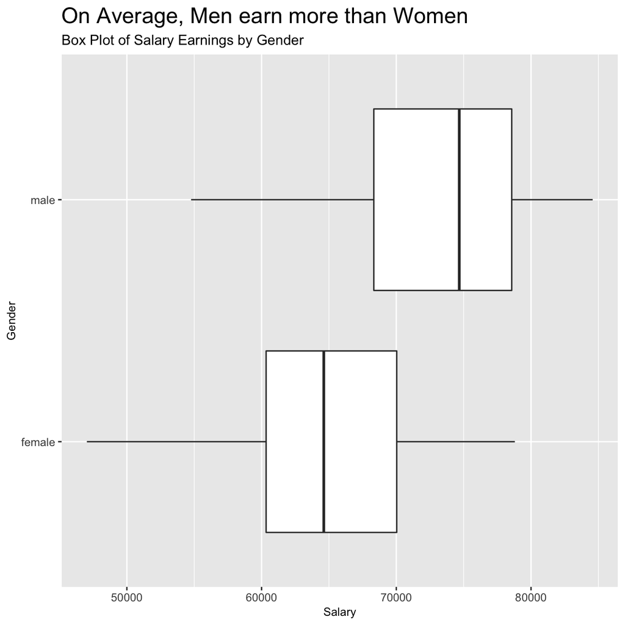

```r
# correlation analysis
salary_plot <- omega %>%
  ggplot(aes(x = salary, y = gender)) +
  geom_boxplot() +
  labs(title = "On Average, Men earn more than Women", subtitle = "Box Plot of Salary Earnings by Gender") + theme(axis.title = element_text(size = 9),
    plot.title = element_text(size = 17)) +labs(x = "Salary", y = "Gender")

salary_plot
```

> Conclusion: Men earn more on average than women, with a considerably higher median salary. The boxplot also indicates that the average salary for each gender is not influenced by outlier values.

Hypothesis testing can also be run, assuming as a null hypothesis that the mean difference in salaries is zero, or that, on average, men and women make the same amount of money. Here we run a hypothesis test using `t.test()` and the simulation method from the `infer` package.

```r
# hypothesis testing using t.test()

ttest <- t.test(salary ~ gender, data = omega)
ttest
```

```
##
##  Welch Two Sample t-test
##
## data:  salary by gender
## t = -4, df = 48, p-value = 2e-04
## alternative hypothesis: true difference in means is not equal to 0
## 95 percent confidence interval:
##  -12973  -4420
## sample estimates:
## mean in group female   mean in group male
##                64543                73239
```

```r
# 95% confidence interval does not include 0, therefore must reject the null hypothesis
# hypothesis testing using infer package


salary_in_null_world <- omega %>%
  specify(salary ~ gender) %>%
  hypothesise(null = "independence") %>%
  generate(reps = 1000, type = "permute") %>%
  calculate(stat = "diff in means",
            order = c("male", "female"))
salary_in_null_world
```

```
## # A tibble: 1,000 x 2
##    replicate     stat
##        <int>    <dbl>
##  1         1    92.9
##  2         2 -1701.
##  3         3 -3527.
##  4         4    -6.28
##  5         5  -411.
##  6         6   465.
##  7         7  1101.
##  8         8  2382.
##  9         9 -1287.
## 10        10 -1205.
## # … with 990 more rows
```

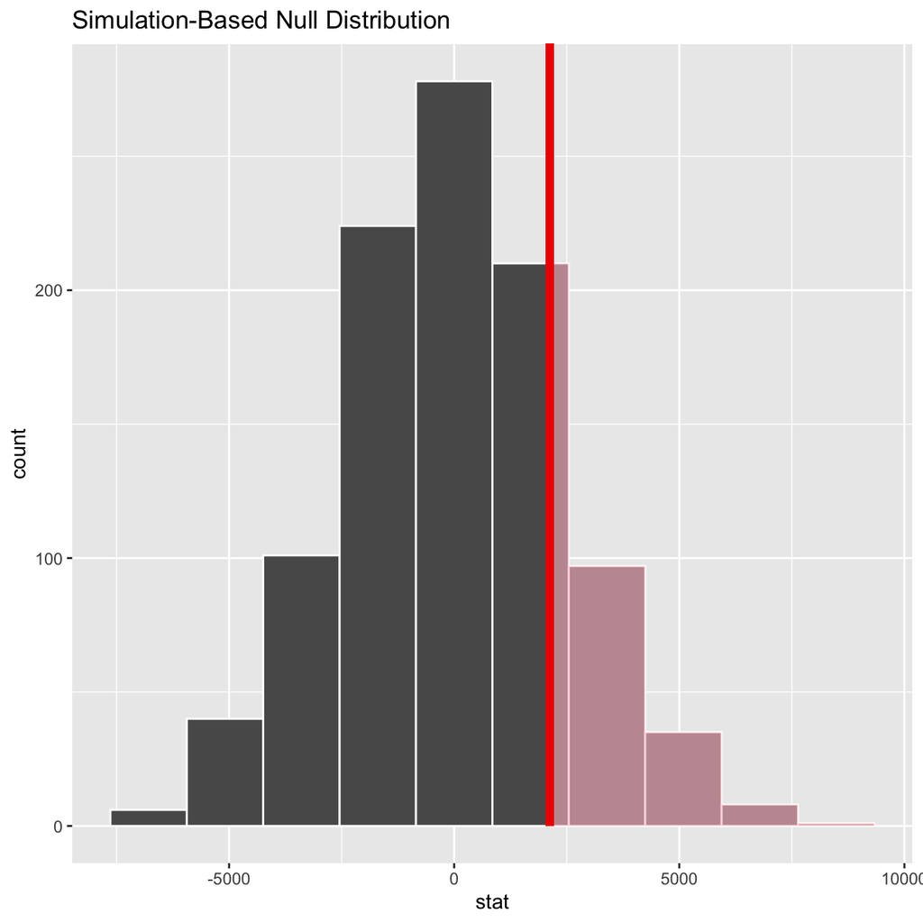

```r
visualise(salary_in_null_world, bins = 10) +
  shade_p_value(obs_stat = ttest$stderr, direction = "right")
```

```r
ttest$stderr
```

```
## [1] 2127
```

> The t-test produces a p-value of 0.0002 which is less than 0.05 (a common threshold for significant results). This shows that the observed sample mean difference is not due to sample error, but because there is a significant difference between the earnings of men and women at Omega.

## Relationship Experience - Gender?

At the board meeting, someone raised the issue that there was indeed a substantial difference between male and female salaries, but that this was attributable to other reasons such as differences in experience. A questionnaire send out to the 50 executives in the sample reveals that the average experience of the men is approximately 21 years, whereas the women only have about 7 years experience on average (see table below).

```r
# Summary Statistics of salary by gender
favstats (experience ~ gender, data=omega)
```

```
##   gender min    Q1 median   Q3 max  mean    sd  n missing
## 1 female   0  0.25    3.0 14.0  29  7.38  8.51 26       0
## 2   male   1 15.75   19.5 31.2  44 21.12 10.92 24       0
```

Based on this evidence, can you conclude that there is a significant difference between the experience of the male and female executives? Perform similar analyses as in the previous section. Does your conclusion validate or endanger your conclusion about the difference in male and female salaries?

```r
# Summary Statistics of salary by gender
favstats (experience ~ gender, data=omega)
```

```
##   gender min    Q1 median   Q3 max  mean    sd  n missing
## 1 female   0  0.25    3.0 14.0  29  7.38  8.51 26       0
## 2   male   1 15.75   19.5 31.2  44 21.12 10.92 24       0
```

```r
omega_experience_ci <- omega %>%
  group_by(gender) %>%
  summarise(mean_experience = mean(experience),
            sd_experience = sd(experience),
            sample_size_exp = n(),
            # get t-critical value with (n-1) degrees of freedom
            t_critical_exp = qt(0.975, sample_size_exp-1),
            se_salary_exp = sd(experience)/sqrt(sample_size_exp),
            margin_of_error_exp = t_critical_exp * se_salary_exp,
            salary_low_exp = mean_experience - margin_of_error_exp,
            salary_high_exp = mean_experience + margin_of_error_exp
  ) %>%
  arrange(desc(mean_experience))
omega_experience_ci
```

```
## # A tibble: 2 x 9
##   gender mean_experience sd_experience sample_size_exp t_critical_exp
##   <chr>            <dbl>         <dbl>           <int>          <dbl>
## 1 male             21.1          10.9               24           2.07
## 2 female            7.38          8.51              26           2.06
## # … with 4 more variables: se_salary_exp <dbl>, margin_of_error_exp <dbl>,
## #   salary_low_exp <dbl>, salary_high_exp <dbl>
```

```r
set.seed(1234)
female_boot_experience <- omega %>%
  filter(gender == "female") %>%
  specify(response = experience) %>%
  generate(reps = 100, type = "bootstrap") %>%
  calculate(stat = "mean")

set.seed(1234)
male_boot_experience <- omega %>%
  filter(gender == "male") %>%
  specify(response = experience) %>%
  generate(reps = 100, type = "bootstrap") %>%
  calculate(stat = "mean")

female_percentile_ci_exp <- female_boot_experience %>%
  get_confidence_interval(level = 0.95, type = "percentile")
female_percentile_ci_exp
```

```
## # A tibble: 1 x 2
##   lower_ci upper_ci
##      <dbl>    <dbl>
## 1     5.13     11.1
```

```r
male_percentile_ci_exp <- male_boot_experience %>%
  get_confidence_interval(level = 0.95, type = "percentile")
male_percentile_ci_exp
```

```
## # A tibble: 1 x 2
##   lower_ci upper_ci
##      <dbl>    <dbl>
## 1     16.3     25.9
```

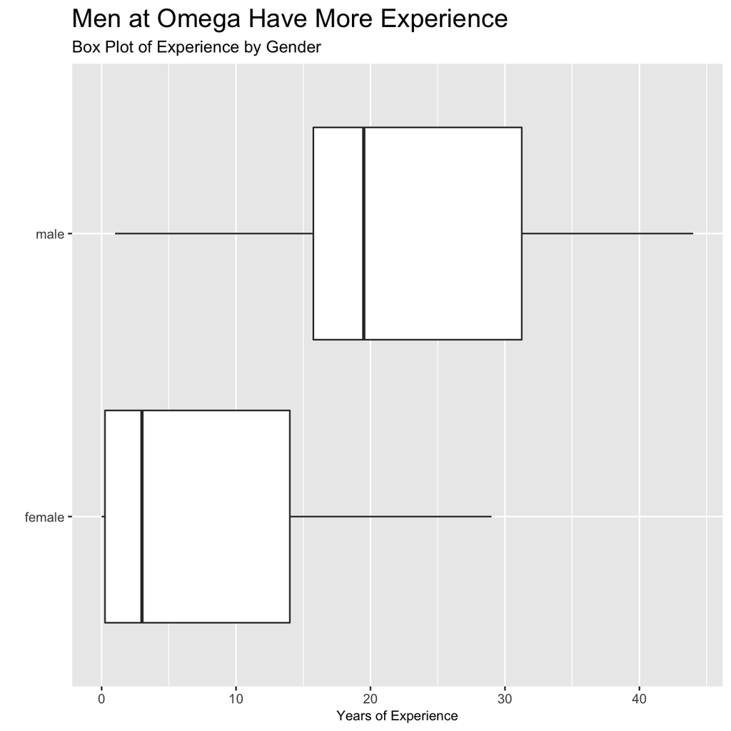

```r
# correlation analysis
experience_plot <- omega %>%
  ggplot(aes(x = experience, y = gender)) +
  geom_boxplot() +
  labs(title = "Men at Omega Have More Experience", subtitle = "Box Plot of Experience by Gender") + theme(axis.title = element_text(size = 9),
    plot.title = element_text(size = 17)) +labs(x = "Years of Experience", y = "")

experience_plot
```

```r
# hypothesis testing using t.test()

ttest_exp <- t.test(experience ~ gender, data = omega)
ttest_exp
```

```
##
##  Welch Two Sample t-test
##
## data:  experience by gender
## t = -5, df = 43, p-value = 1e-05
## alternative hypothesis: true difference in means is not equal to 0
## 95 percent confidence interval:
##  -19.35  -8.13
## sample estimates:
## mean in group female   mean in group male
##                 7.38                21.12
```

```r
# 95% confidence interval does not include 0, therefore must reject the null hypothesis
# hypothesis testing using infer package


experience_in_null_world <- omega %>%
  specify(experience ~ gender) %>%
  hypothesise(null = "independence") %>%
  generate(reps = 1000, type = "permute") %>%
  calculate(stat = "diff in means",
            order = c("male", "female"))
experience_in_null_world
```

```
## # A tibble: 1,000 x 2
##    replicate   stat
##        <int>  <dbl>
##  1         1  0.519
##  2         2 -3.65
##  3         3 -4.85
##  4         4  1.32
##  5         5 -1.48
##  6         6 -2.12
##  7         7  0.599
##  8         8  0.760
##  9         9 -3.97
## 10        10  0.359
## # … with 990 more rows
```

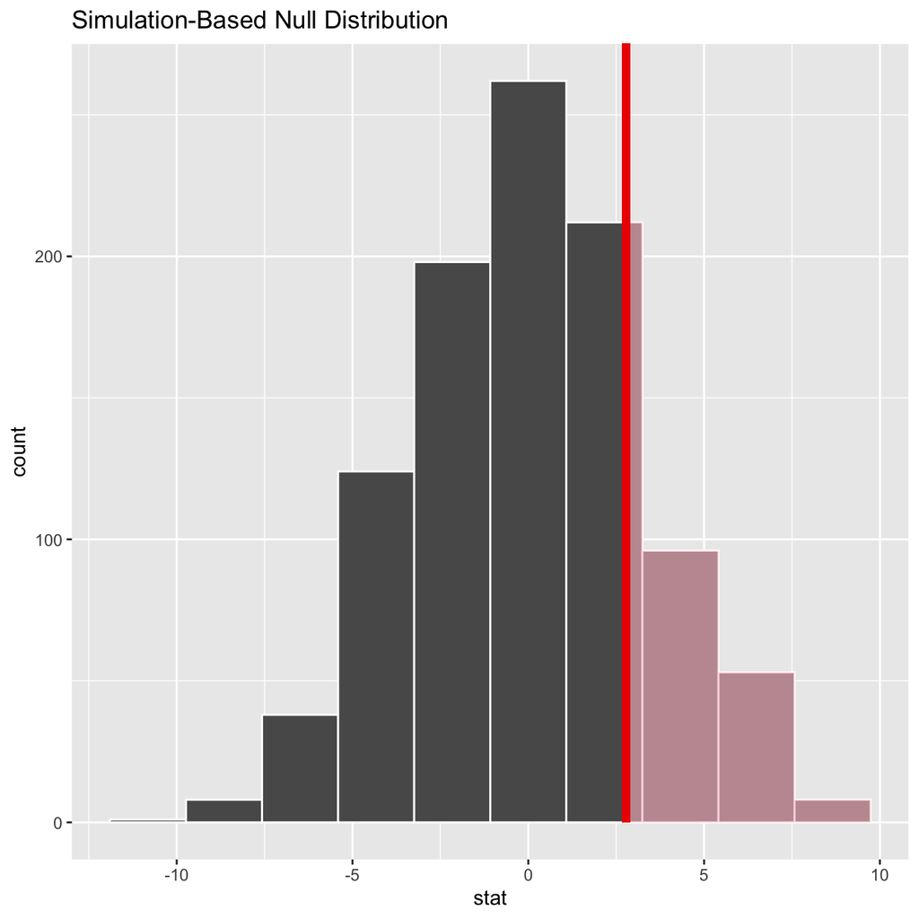

```r
visualise(experience_in_null_world, bins = 10) +
  shade_p_value(obs_stat = ttest_exp$stderr, direction = "right")
```

```r
ttest_exp$stderr
```

```
## [1] 2.78
```

> After conducting the same analysis on years of experience, we can see that men have considerably more experience than women. From t-tests and hypothesis testing, we calculated a p-value of 0.00001, suggesting that the observed sample mean difference is statistically significant, and not due to sampling error. Consequently, this means that the discrepencies in salary between men and women cannot necessarily be explained by gender, but may be due to the difference in experience between genders.

## Relationship Salary - Experience ?

Someone at the meeting argues that clearly, a more thorough analysis of the relationship between salary and experience is required before any conclusion can be drawn about whether there is any gender-based salary discrimination in the company.

Analyse the relationship between salary and experience. Draw a scatterplot to visually inspect the data

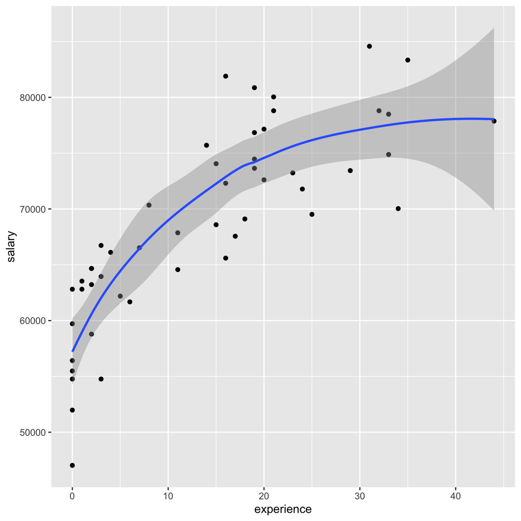

```r
ggplot(data = omega, aes( x = experience, y = salary)) +
  geom_point() +
  geom_smooth()
```

> The scatterplot shows a positive relationship between salary and experience. While correlation does not necessarily imply causation, in this case we have also explored other factors such as gender. Therefore it is possible that more years of experience does result in a higher salary.

## Check correlations between the data

We used `GGally:ggpairs()` to create a scatterplot and correlation matrix. Essentially, this changes the order our variables will appear in and have the dependent variable (Y), salary, as last in our list. We then pipe the dataframe to `ggpairs()` with `aes` arguments to colour by `gender` and make the plots somewhat transparent (`alpha = 0.3`).

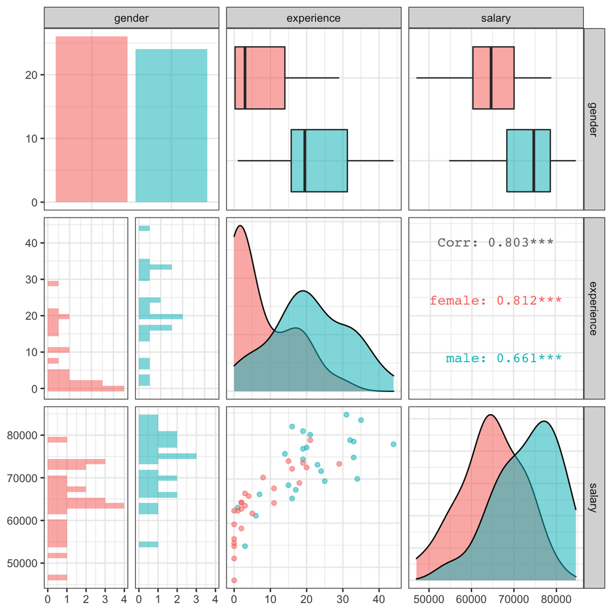

```r
omega %>%
  select(gender, experience, salary) %>% #order variables they will appear in ggpairs()
  ggpairs(aes(colour=gender, alpha = 0.3))+
  theme_bw()
```

> The salary vs experience scatterplot indicates that more experience results in a higher salary, regardless of gender. This suggests that rather than gender-based salary discrimination, the difference in salary between men and women is due to men at Omega having more experience, and more experience correlates to a higher salary.